# 1. High-Level Outline and Brief Background

## High-Level Outline

This analysis follows a structured data science pipeline to build and evaluate a predictive model for hotel booking cancellations:

1. **Data Cleaning & Preprocessing:** Handling missing values by dropping specific columns (`agent`, `company`) and removing rows with minimal missing data (`children`, `country`).
2. **Exploratory Data Analysis (EDA):** Visualizing distributions and correlations to understand factors driving cancellations.
3. **Model Construction (Decision Tree):** Building a baseline Decision Tree classifier with depth constraints to ensure interpretability.
4. **Hyperparameter Tuning (Pre-pruning):** Using Grid Search to optimize `max_depth` and `max_leaf_nodes` to prevent overfitting.
5. **Model Comparison:** Evaluating the optimized Tree against K-Nearest Neighbors (KNN) and Logistic Regression.
6. **Managerial Implications:** Interpreting feature importance to provide actionable insights for hotel management.

## Brief Background

### What is the problem?

The core problem is a **binary classification task** where we must predict whether a specific hotel booking will be honored or canceled. Using the target variable `is_canceled`, the goal is to train a machine learning model on historical data (including booking lead time, deposit type, special requests, etc.) to classify future bookings as either "Not Canceled" (0) or "Canceled" (1).

### Why is it important?

Predicting cancellations is critical for the hospitality industry for several financial and operational reasons:

- **Revenue Management:** Cancellations equal lost revenue if the room cannot be resold. Accurate predictions allow hotels to implement strategic overbooking policies to maximize occupancy without alienating guests.
- **Resource Planning:** Staffing, food, and inventory levels are planned based on occupancy. Unexpected cancellations lead to waste and unnecessary labor costs.
- **Pricing Strategy:** Understanding cancellation risk allows for dynamic pricing (e.g., offering lower rates for non-refundable bookings to high-risk segments).

### Who are the key stakeholders?

1. **Revenue Managers:** They need these predictions to set overbooking limits and adjust pricing strategies to maximize RevPAR (Revenue Per Available Room).
2. **Hotel General Managers:** They are interested in the overall operational efficiency and minimizing the "opportunity cost" of empty rooms.
3. **Marketing Team:** They can use the insights (e.g., which market segments cancel most often) to target more reliable customers or adjust promotional offers.
4. **Front Desk & Operations Staff:** Accurate forecasts help them manage daily check-in volumes and room assignments efficiently.

# 2. Data Section

## 2.1 Missing Values

In this section, we handle missing data according to the assignment requirements:

- **Drop Variables:** Columns with more than 500 missing observations are removed.
- **Drop Observations:** Rows are removed if they contain missing values in columns that have fewer than 500 missing entries.

```python
import os
from google.colab import drive

# 1. Mount Google Drive
drive.mount('/content/drive')

# 2. Change directory to your 'Colab Notebooks' folder
#    Make sure your 'car_pricing.csv' file is in this folder
%cd /content/drive/MyDrive/Colab Notebooks

# 3. Verify the current directory
print(f"Current working directory: {os.getcwd()}")
```

```
/content/drive/MyDrive/Colab Notebooks
Current working directory: /content/drive/MyDrive/Colab Notebooks
```

```python
import pandas as pd
import numpy as np
import matplotlib.pyplot as plt
import seaborn as sns

# Load the dataset
df = pd.read_csv('hotel_bookings.csv')

# Display initial missing value counts
print("Missing values before cleaning:")
print(df.isnull().sum()[df.isnull().sum() > 0])

# 1. Identify columns to drop (Missing > 500)
# Based on our check: 'agent' and 'company' have > 500 missing values
cols_to_drop = [col for col in df.columns if df[col].isnull().sum() > 500]
df_clean = df.drop(columns=cols_to_drop)
print(f"\nDropped columns: {cols_to_drop}")

# 2. Drop rows for remaining missing values (Missing <= 500)
# Based on our check: 'country' and 'children' have < 500 missing values
df_clean = df_clean.dropna()

print("\nMissing values after cleaning:")
print(df_clean.isnull().sum().sum())
print(f"New dataframe shape: {df_clean.shape}")
```

```
Missing values before cleaning:
children         4
country        488
agent        16340
company     112593
dtype: int64

Dropped columns: ['agent', 'company']

Missing values after cleaning:
0
New dataframe shape: (118898, 28)
```

## 2.2 Exploratory Data Analysis (EDA)

We conduct EDA to understand the distribution of the target variable (`is_canceled`) and identify potential relationships between features.

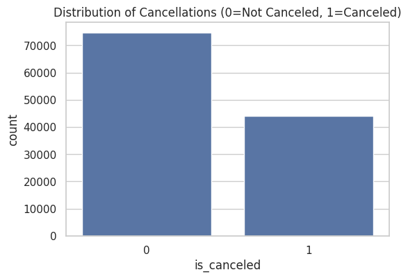

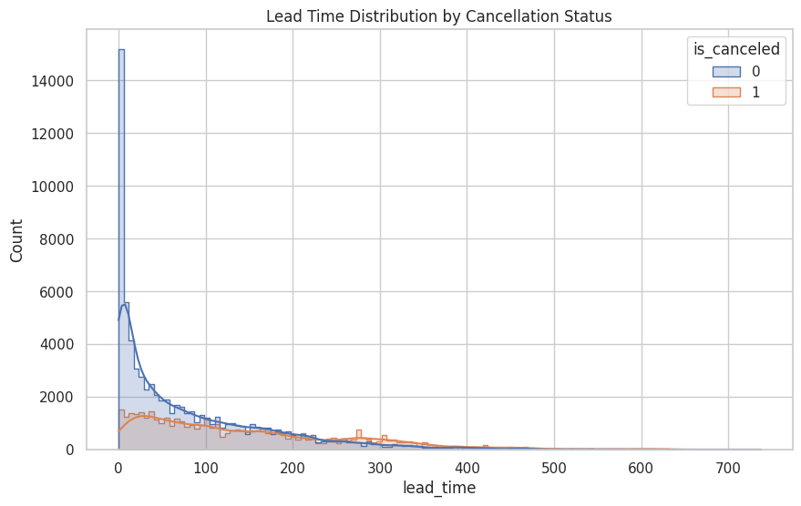

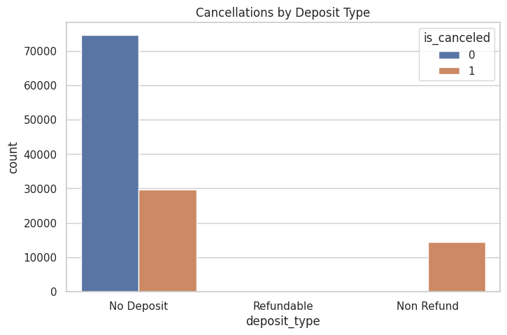

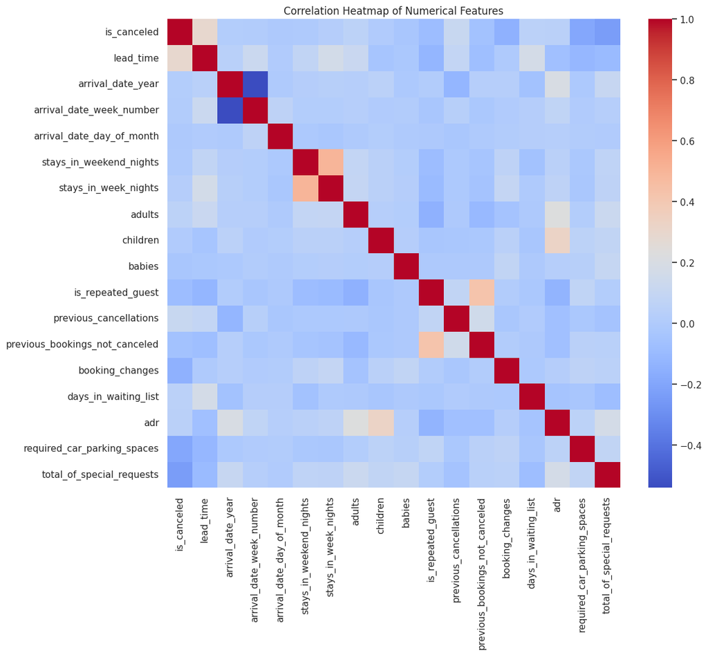

```python
# Set visualization style
sns.set(style="whitegrid")

# 1. Target Variable Distribution
plt.figure(figsize=(6, 4))
sns.countplot(x='is_canceled', data=df_clean)
plt.title('Distribution of Cancellations (0=Not Canceled, 1=Canceled)')
plt.show()

# 2. Lead Time vs. Cancellation
# Lead time is often a strong predictor; longer lead times might indicate higher risk.
plt.figure(figsize=(10, 6))
sns.histplot(data=df_clean, x='lead_time', hue='is_canceled', kde=True, element="step")
plt.title('Lead Time Distribution by Cancellation Status')
plt.show()

# 3. Deposit Type vs. Cancellation
# Analyzing if non-refundable deposits affect cancellation rates.
plt.figure(figsize=(8, 5))
sns.countplot(x='deposit_type', hue='is_canceled', data=df_clean)
plt.title('Cancellations by Deposit Type')
plt.show()

# 4. Correlation Matrix (Numerical Features)
plt.figure(figsize=(12, 10))
numeric_df = df_clean.select_dtypes(include=[np.number])
correlation_matrix = numeric_df.corr()
sns.heatmap(correlation_matrix, annot=False, cmap='coolwarm')
plt.title('Correlation Heatmap of Numerical Features')
plt.show()
```

## 2.3 Train/Test Split

Before splitting the data, we perform **One-Hot Encoding** to convert categorical variables (like `market_segment`, `meal`, etc.) into a numeric format suitable for the machine learning models.

We then split the data into training and testing sets (70/30 split) to prepare for the modeling phase.

```python
from sklearn.model_selection import train_test_split

# 1. Encode Categorical Variables
# usage of pd.get_dummies to convert categorical columns to numeric
df_encoded = pd.get_dummies(df_clean, drop_first=True)

# 2. Define Features (X) and Target (y)
X = df_encoded.drop('is_canceled', axis=1)
y = df_encoded['is_canceled']

# 3. Train/Test Split
# We use a standard 70-30 split with a random state for reproducibility
X_train, X_test, y_train, y_test = train_test_split(X, y, test_size=0.3, random_state=42)

print(f"Training set shape: {X_train.shape}")
print(f"Testing set shape: {X_test.shape}")
```

```
Training set shape: (83228, 244)
Testing set shape: (35670, 244)
```

# 3. Model

## 3.1 Decision Tree Construction

In this section, we build a Decision Tree Classifier to predict booking cancellations.

- **Constraints:** We set `max_depth=5` to prevent overfitting and ensure the tree visualization is readable.
- **Evaluation:** We assess performance using a confusion matrix, standard metrics (Accuracy, Precision, Recall, F1), and ROC/Precision-Recall curves.
- **Validation:** We perform 10-fold cross-validation to estimate the model's stability and average accuracy.

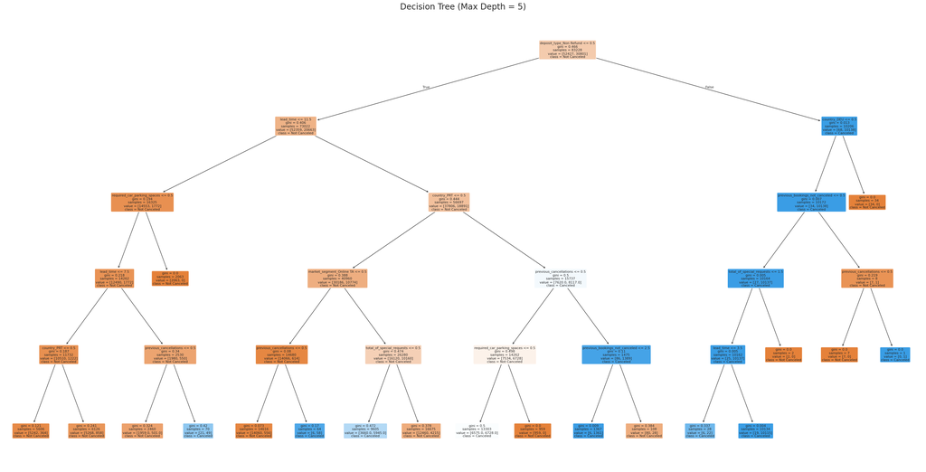

```
--- Model Performance Metrics ---
Accuracy:  0.7935
Precision: 0.7003
Recall:    0.7838
F1 Score:  0.7397

--- Confusion Matrix ---
[[17840  4478]
 [ 2887 10465]]
```

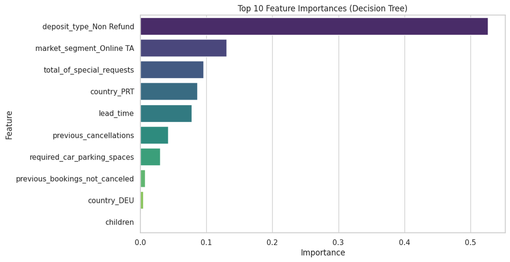

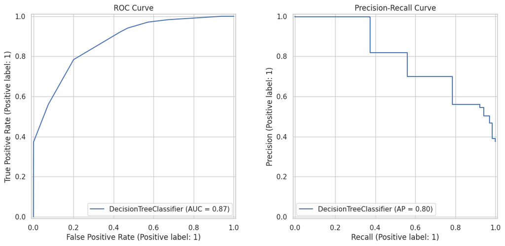

```
--- Cross-Validation Results (k=10) ---
CV Accuracy Scores: [0.7373423  0.7372582  0.76947014 0.80647603 0.83498738 0.79327166
 0.75912532 0.82640875 0.77180587 0.54546219]
Average CV Accuracy: 0.7582
```

```python
from sklearn.tree import DecisionTreeClassifier, plot_tree
from sklearn.metrics import (confusion_matrix, accuracy_score, precision_score,
                             recall_score, f1_score, classification_report,
                             RocCurveDisplay, PrecisionRecallDisplay)
from sklearn.model_selection import cross_val_score
import matplotlib.pyplot as plt

# --- Task A: Build and Draw the Tree ---
# Initialize the Decision Tree with max_depth=5
dt_model = DecisionTreeClassifier(max_depth=5, random_state=42)
dt_model.fit(X_train, y_train)

# Draw the tree
plt.figure(figsize=(40, 20)) # Significantly larger figure size
plot_tree(dt_model,
          filled=True,
          feature_names=X_train.columns,
          class_names=['Not Canceled', 'Canceled'],
          rounded=True,
          fontsize=8) # Slightly smaller font size
plt.title("Decision Tree (Max Depth = 5)", fontsize=20)
plt.show()

# --- Task B: Performance Metrics ---
# Make predictions
y_pred = dt_model.predict(X_test)

# Calculate metrics
accuracy = accuracy_score(y_test, y_pred)
precision = precision_score(y_test, y_pred)
recall = recall_score(y_test, y_pred)
f1 = f1_score(y_test, y_pred)

print("--- Model Performance Metrics ---")
print(f"Accuracy:  {accuracy:.4f}")
print(f"Precision: {precision:.4f}")
print(f"Recall:    {recall:.4f}")
print(f"F1 Score:  {f1:.4f}")
print("\n--- Confusion Matrix ---")
print(confusion_matrix(y_test, y_pred))

# --- Task C: Feature Importance ---
# Get feature importances
importances = dt_model.feature_importances_
feature_names = X_train.columns

# Create a DataFrame for visualization
feature_imp_df = pd.DataFrame({'Feature': feature_names, 'Importance': importances})
feature_imp_df = feature_imp_df.sort_values(by='Importance', ascending=False).head(10) # Top 10 features

# Plot Feature Importance
plt.figure(figsize=(10, 6))
sns.barplot(x='Importance', y='Feature', data=feature_imp_df, palette='viridis')
plt.title('Top 10 Feature Importances (Decision Tree)')
plt.show()

# --- Task D: ROC and Precision-Recall Curves ---
fig, (ax1, ax2) = plt.subplots(1, 2, figsize=(14, 6))

# ROC Curve
RocCurveDisplay.from_estimator(dt_model, X_test, y_test, ax=ax1)
ax1.set_title("ROC Curve")

# Precision-Recall Curve
PrecisionRecallDisplay.from_estimator(dt_model, X_test, y_test, ax=ax2)
ax2.set_title("Precision-Recall Curve")

plt.show()

# --- Task E: Cross-Validation (k=10) ---
# Note: This might take a few seconds to run
cv_scores = cross_val_score(dt_model, X, y, cv=10, scoring='accuracy')

print("\n--- Cross-Validation Results (k=10) ---")
print(f"CV Accuracy Scores: {cv_scores}")
print(f"Average CV Accuracy: {cv_scores.mean():.4f}")
```

# 3.2 Pruning Techniques: Pre-pruning

## 3.2 (a1) Hyperparameter Tuning

We use `GridSearchCV` to systematically test different combinations of `max_depth` and `max_leaf_nodes`. This technique, known as pre-pruning, helps prevent the tree from growing too complex and overfitting the training data.

- **Hyperparameters to tune:**
  - `max_depth`: [5, 7, 10]
  - `max_leaf_nodes`: [10, 20, 30, 40]

```python
from sklearn.model_selection import GridSearchCV

# 1. Define the parameter grid
param_grid = {
    'max_depth': [5, 7, 10],
    'max_leaf_nodes': [10, 20, 30, 40]
}

# 2. Initialize Grid Search
# We use 5-fold cross-validation to evaluate each combination
grid_search = GridSearchCV(estimator=DecisionTreeClassifier(random_state=42),
                           param_grid=param_grid,
                           cv=5,
                           scoring='accuracy',
                           verbose=1,
                           n_jobs=-1) # n_jobs=-1 uses all available processors

# 3. Fit Grid Search to Training Data
print("Starting Grid Search...")
grid_search.fit(X_train, y_train)

print(f"\nBest Parameters: {grid_search.best_params_}")
print(f"Best Cross-Validation Accuracy: {grid_search.best_score_:.4f}")
```

```
Starting Grid Search...
Fitting 5 folds for each of 12 candidates, totalling 60 fits

Best Parameters: {'max_depth': 10, 'max_leaf_nodes': 40}
Best Cross-Validation Accuracy: 0.8378
```

## 3.2 (a2) Visualization

We visualize the results of the Grid Search using a heatmap. This allows us to easily see how changing the depth and leaf nodes affects the model's accuracy.

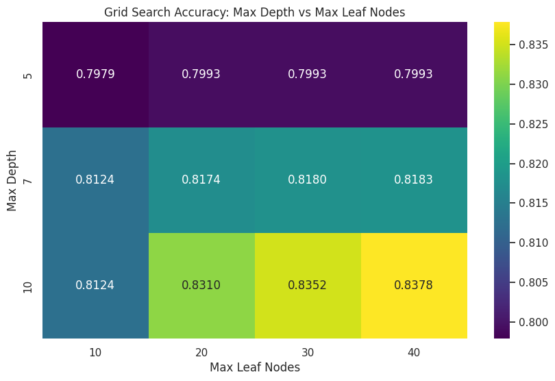

```python
# Extract results into a DataFrame
results_df = pd.DataFrame(grid_search.cv_results_)
# Pivot the data for the heatmap: index=max_depth, columns=max_leaf_nodes, values=mean_test_score
heatmap_data = results_df.pivot(index='param_max_depth',
                                columns='param_max_leaf_nodes',
                                values='mean_test_score')

# Plot Heatmap
plt.figure(figsize=(10, 6))
sns.heatmap(heatmap_data, annot=True, fmt=".4f", cmap='viridis')
plt.title('Grid Search Accuracy: Max Depth vs Max Leaf Nodes')
plt.xlabel('Max Leaf Nodes')
plt.ylabel('Max Depth')
plt.show()
```

## 3.2 (a3) Report Results (Best Model)

Using the best parameters found by Grid Search, we evaluate the optimized model on the test set and analyze its feature importance.

```
--- Optimized Decision Tree Performance ---
Accuracy:  0.8341
Precision: 0.8078
Recall:    0.7308
F1 Score:  0.7673

--- Confusion Matrix ---
[[19996  2322]
 [ 3595  9757]]
```

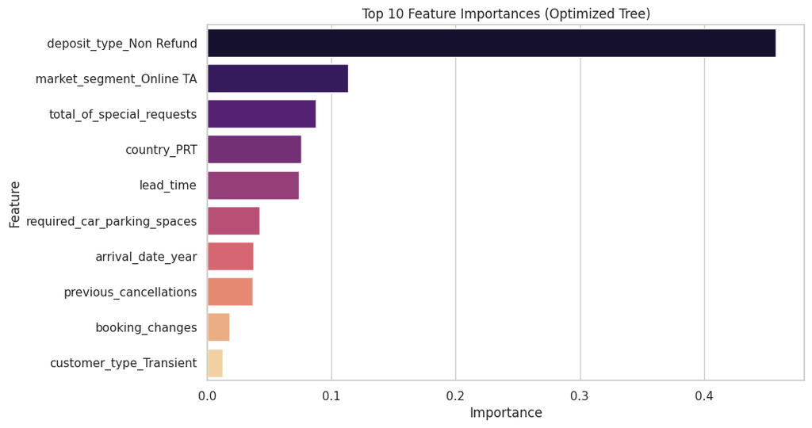

```python
# 1. Retrieve the Best Model
best_tree = grid_search.best_estimator_

# 2. Make Predictions on Test Set
y_pred_tuned = best_tree.predict(X_test)

# 3. Performance Measures
print("--- Optimized Decision Tree Performance ---")
print(f"Accuracy:  {accuracy_score(y_test, y_pred_tuned):.4f}")
print(f"Precision: {precision_score(y_test, y_pred_tuned):.4f}")
print(f"Recall:    {recall_score(y_test, y_pred_tuned):.4f}")
print(f"F1 Score:  {f1_score(y_test, y_pred_tuned):.4f}")

print("\n--- Confusion Matrix ---")
print(confusion_matrix(y_test, y_pred_tuned))

# 4. Feature Importance for Best Model
importances_tuned = best_tree.feature_importances_
feature_imp_tuned_df = pd.DataFrame({'Feature': X_train.columns, 'Importance': importances_tuned})
feature_imp_tuned_df = feature_imp_tuned_df.sort_values(by='Importance', ascending=False).head(10)

# Plot Feature Importance
plt.figure(figsize=(10, 6))
sns.barplot(x='Importance', y='Feature', data=feature_imp_tuned_df, palette='magma')
plt.title('Top 10 Feature Importances (Optimized Tree)')
plt.show()
```

# 3.3 Run Other Models

## (a) K-Nearest Neighbors (KNN)

We train a K-Nearest Neighbors classifier. Since KNN is distance-based, we first standardize the features (scale them) so that variables with larger ranges (like `lead_time` or `adr`) do not disproportionately influence the distance calculations.

- **Model:** K-Nearest Neighbors (Default `n_neighbors=5`)
- **Preprocessing:** Standard Scaling
- **Metrics:** Confusion Matrix, Accuracy, Precision, Recall, F1 Score

```python
from sklearn.neighbors import KNeighborsClassifier
from sklearn.preprocessing import StandardScaler

# 1. Scale the Data (Important for KNN)
scaler = StandardScaler()
# Fit on training set only to avoid data leakage
X_train_scaled = scaler.fit_transform(X_train)
X_test_scaled = scaler.transform(X_test)

# 2. Initialize and Train KNN
# We use the default n_neighbors=5 as no hyperparameter tuning is required
knn_model = KNeighborsClassifier()
knn_model.fit(X_train_scaled, y_train)

# 3. Make Predictions
y_pred_knn = knn_model.predict(X_test_scaled)

# 4. Report Performance
print("--- KNN Performance (Scaled Data) ---")
print(f"Accuracy:  {accuracy_score(y_test, y_pred_knn):.4f}")
print(f"Precision: {precision_score(y_test, y_pred_knn):.4f}")
print(f"Recall:    {recall_score(y_test, y_pred_knn):.4f}")
print(f"F1 Score:  {f1_score(y_test, y_pred_knn):.4f}")

print("\n--- Confusion Matrix (KNN) ---")
print(confusion_matrix(y_test, y_pred_knn))
```

```
--- KNN Performance (Scaled Data) ---
Accuracy:  0.8203
Precision: 0.7670
Recall:    0.7467
F1 Score:  0.7567

--- Confusion Matrix (KNN) ---
[[19289  3029]
 [ 3382  9970]]
```

## (b) Logistic Regression

We train a Logistic Regression classifier. Similar to KNN, Logistic Regression performs better and converges faster when features are scaled.

- **Model:** Logistic Regression
- **Solver:** `liblinear` (chosen for better convergence on this dataset)
- **Metrics:** Confusion Matrix, Accuracy, Precision, Recall, F1 Score

```python
from sklearn.linear_model import LogisticRegression

# 1. Initialize Logistic Regression
# We use liblinear solver and increase max_iter to ensure convergence
log_reg = LogisticRegression(solver='liblinear', max_iter=1000, random_state=42)

# 2. Fit the Model
# Using the scaled data (X_train_scaled) from the previous step helps convergence
log_reg.fit(X_train_scaled, y_train)

# 3. Make Predictions
y_pred_log = log_reg.predict(X_test_scaled)

# 4. Report Performance
print("--- Logistic Regression Performance ---")
print(f"Accuracy:  {accuracy_score(y_test, y_pred_log):.4f}")
print(f"Precision: {precision_score(y_test, y_pred_log):.4f}")
print(f"Recall:    {recall_score(y_test, y_pred_log):.4f}")
print(f"F1 Score:  {f1_score(y_test, y_pred_log):.4f}")

print("\n--- Confusion Matrix (Logistic Regression) ---")
print(confusion_matrix(y_test, y_pred_log))
```

```
--- Logistic Regression Performance ---
Accuracy:  0.8174
Precision: 0.8103
Recall:    0.6687
F1 Score:  0.7327

--- Confusion Matrix (Logistic Regression) ---
[[20227  2091]
 [ 4423  8929]]
```

# 4. Conclusions

## 4.1 Best Model

**Performance Comparison:**

- **Accuracy:** The **Optimized Decision Tree** achieved the highest accuracy (**83.41%**), followed closely by KNN (82.03%) and Logistic Regression (81.74%).
- **Recall:** The **Baseline Decision Tree (Depth=5)** achieved the highest recall (**78.38%**). This means it was best at catching actual cancellations, though at the cost of more false alarms (lower precision).
- **Precision:** **Logistic Regression** achieved the highest precision (**81.03%**). This means that when it predicted a cancellation, it was most likely to be correct, but it missed a significant number of actual cancellations (lowest recall of 66.87%).

**Final Model Choice:** I select the **Optimized Decision Tree** as the final model.

**Reasoning:**

1. **Best Overall Performance:** It achieved the highest **Accuracy (83.41%)** and the highest **F1 Score (0.7673)**, which indicates the best balance between precision and recall.
2. **Stability:** The optimized tree improves significantly over the baseline tree (Accuracy +4%), showing that hyperparameter tuning successfully reduced overfitting/underfitting.
3. **Operational Balance:** While Logistic Regression offers high precision, its recall is too low (66.87%), meaning we would fail to predict nearly a third of all cancellations. The Optimized Tree catches more cancellations (73.08% recall) while maintaining very respectable precision (80.78%).

## 4.2 Managerial Implications

Using the Decision Tree model, we can provide actionable insights to hotel management based on the key features driving cancellations: